# Assignment 10

Zain Awan

### Note On Tardiness

This assignment was submitted late due to a 5 day military training event. I had asked the professor for an extension a week before the assignment was due. Please do not apply the late penalty when grading this assignment.

# Question 1

```r
# Load libraries and datasets
library(openintro)
library(psych)
library(dplyr)
data(ncbirths)
```

## Confidence Interval

A confidence interval may be conceptualized as a type of margin of error in the world of statistics. For example, if we say that we have a CI of 95% we are saying that the proportion of the data is innacurate or an outlier is equal to 5%. This is typically the 2.5% top and bottom values.

## Prediction Interval

A prediction interval assigns the probability that a future observtion will be a certain value based on previous observations. The value in a prediction interval is also normally a range of values. As an example we would say something like we are 95% confident the next value will be in the range of [1:10].

# Quetion 2

cor() only accepts values of type numeric so we must convert them. Thankfully the columns are categorical data that is easily converted.

```r
ncbirths <- ncbirths %>%
  mutate(premie_numeric = ifelse(premie == "premie", 0,1)) %>% # fullterm = 1
  mutate(mature_nuneric = ifelse(mature == "mature", 1,0)) %>% # mature = 1
  mutate(marital_numeric = ifelse(marital == "married", 1, 0)) %>% # married = 1
  mutate(lowbirthweight_numeric = ifelse(lowbirthweight == "low", 1,0)) %>% # low = 1
  mutate(gender_numeric = ifelse(gender == "male", 1,0)) %>% # male = 1
  mutate(habit_numeric = ifelse(habit == "smoker", 1,0)) %>% # smoker = 1
  mutate(whitemom_numeric = ifelse(whitemom == "white", 1,0)) # whitemom = 1

ncbirths_numeric <- ncbirths %>%
  select(fage,mage,weeks,visits,gained,weight,premie_numeric,marital_numeric,mature_nuneric,lowbirthweight_numeric,gender_numeric,habit_numeric,whitemom_numeric)

# use = pairwise.complete.obs to remove NA values
cor(ncbirths_numeric, use = "pairwise.complete.obs")
```

```
##                                fage         mage       weeks      visits
## fage                    1.000000000  0.780506784 -0.01607193  0.08138687
## mage                    0.780506784  1.000000000 -0.03208743  0.16062202
## weeks                  -0.016071926 -0.032087430  1.00000000  0.17613607
## visits                  0.081386874  0.160622020  0.17613607  1.00000000
## gained                 -0.043100500 -0.060635332  0.09140028  0.05986466
## weight                  0.070234033  0.055065889  0.67010134  0.13488301
## premie_numeric         -0.003744287  0.007245640  0.73556200  0.14622240
## marital_numeric         0.346213418  0.438367519  0.06894203  0.22936582
## mature_nuneric                   NA           NA          NA          NA
## lowbirthweight_numeric  0.002575852 -0.002050325 -0.58946900 -0.11578024
## gender_numeric          0.059039112 -0.008695144  0.01915347 -0.04025309
## habit_numeric          -0.088674254 -0.106655019  0.01424134 -0.07390453
## whitemom_numeric        0.115915133  0.168694281  0.09792439  0.07672623
##                             gained      weight premie_numeric marital_numeric
## fage                   -0.04310050  0.07023403   -0.003744287     0.346213418
## mage                   -0.06063533  0.05506589    0.007245640     0.438367519
## weeks                   0.09140028  0.67010134    0.735561997     0.068942032
## visits                  0.05986466  0.13488301    0.146222396     0.229365818
## gained                  1.00000000  0.15417155    0.133239649     0.024919823
## weight                  0.15417155  1.00000000    0.556294999     0.160184652
## premie_numeric          0.13323965  0.55629500    1.000000000     0.087095443
## marital_numeric         0.02491982  0.16018465    0.087095443     1.000000000
## mature_nuneric                  NA          NA             NA              NA
## lowbirthweight_numeric -0.10326528 -0.71842742   -0.563192923    -0.121480719
## gender_numeric          0.03610051  0.13215890   -0.030435326     0.004251541
## habit_numeric           0.04257223 -0.06961297    0.001598465    -0.107220940
## whitemom_numeric        0.07304234  0.15900409    0.078280577     0.330148687
##                        mature_nuneric lowbirthweight_numeric gender_numeric
## fage                               NA            0.002575852    0.059039112
## mage                               NA           -0.002050325   -0.008695144
## weeks                              NA           -0.589469004    0.019153469
## visits                             NA           -0.115780244   -0.040253087
## gained                             NA           -0.103265281    0.036100511
## weight                             NA           -0.718427419    0.132158904
## premie_numeric                     NA           -0.563192923   -0.030435326
## marital_numeric                    NA           -0.121480719    0.004251541
## mature_nuneric                     NA                     NA             NA
## lowbirthweight_numeric             NA            1.000000000   -0.020163852
## gender_numeric                     NA           -0.020163852    1.000000000
## habit_numeric                      NA            0.039743707    0.038083607
## whitemom_numeric                   NA           -0.080610599   -0.031705094
##                        habit_numeric whitemom_numeric
## fage                    -0.088674254       0.11591513
## mage                    -0.106655019       0.16869428
## weeks                    0.014241340       0.09792439
## visits                  -0.073904533       0.07672623
## gained                   0.042572229       0.07304234
## weight                  -0.069612974       0.15900409
## premie_numeric           0.001598465       0.07828058
## marital_numeric         -0.107220940       0.33014869
## mature_nuneric                    NA               NA
## lowbirthweight_numeric   0.039743707      -0.08061060
## gender_numeric           0.038083607      -0.03170509
## habit_numeric            1.000000000       0.03940358
## whitemom_numeric         0.039403578       1.00000000
```

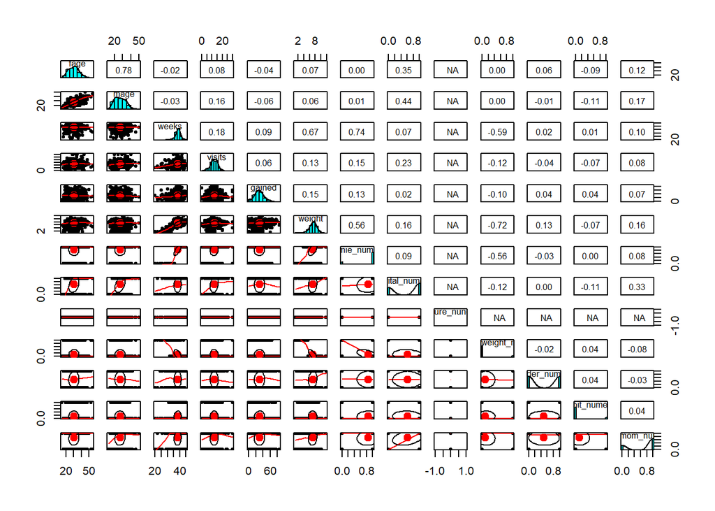

```r
# Create paired correlation plots to visualize the data
pairs.panels(ncbirths_numeric, use = "pairwise.complete.obs")
```

## Distribution

Father Age: Right skew. Majority of fathers tend to be younger and a few older fathers are increasing the mean.  
Mother Age: Right skew. Majority of mothers tend to be younger and a few older mothers are increasing the mean.  
Weeks: Left skew. Majority of births tend to take place after 30 weeks.  
Visits: Normal distributiion.  
Gained: Right skew. The amount of weight gained during pregnancy is not that much.  
Weight: Left skew. Low weight babies from premature births lower the mean.  
Premie: Majority of births occur after a full term pregnancy.  
Marital: Majority of births occur from married couples.  
Low Birth Weight: Majority of babies are not born with low weight.  
Gender: Evenly distributed.  
Habit: Majority of mothers are non smokers.  
White Mom: Majority of mothers are white.

# Question 3

From the summary below the model to predict the weight of a baby is: weight = -4.61 + 0(fage) + 0(mage) + 0.26(weeks) + 0(visits) + 0(gained) + 0.61(premie_numeric) + 0.21(marital) + 0.39(gender) - 0.30(habit) + 0.29(whitemom)

```r
m <- lm(weight ~ fage+mage+weeks+visits+gained+premie_numeric+marital_numeric+gender_numeric+habit_numeric+whitemom_numeric, data = ncbirths_numeric)
summary(m)
```

```
##
## Call:
## lm(formula = weight ~ fage + mage + weeks + visits + gained +
##     premie_numeric + marital_numeric + gender_numeric + habit_numeric +
##     whitemom_numeric, data = ncbirths_numeric)
##
## Residuals:
##     Min      1Q  Median      3Q     Max
## -3.7438 -0.6576 -0.0143  0.6790  3.6576
##
## Coefficients:
##                   Estimate Std. Error t value Pr(>|t|)
## (Intercept)      -4.613779   0.708445  -6.513 1.31e-10 ***
## fage              0.004543   0.008963   0.507 0.612403
## mage              0.002701   0.010190   0.265 0.791002
## weeks             0.264946   0.020107  13.177  < 2e-16 ***
## visits            0.004483   0.010349   0.433 0.665026
## gained            0.009093   0.002714   3.351 0.000844 ***
## premie_numeric    0.619446   0.162369   3.815 0.000147 ***
## marital_numeric   0.215704   0.095622   2.256 0.024356 *
## gender_numeric    0.399191   0.075854   5.263 1.83e-07 ***
## habit_numeric    -0.304207   0.123840  -2.456 0.014246 *
## whitemom_numeric  0.291236   0.093304   3.121 0.001866 **
## ---
## Signif. codes:  0 '***' 0.001 '**' 0.01 '*' 0.05 '.' 0.1 ' ' 1
##
## Residual standard error: 1.061 on 789 degrees of freedom
##   (200 observations deleted due to missingness)
## Multiple R-squared:  0.4643, Adjusted R-squared:  0.4575
## F-statistic: 68.39 on 10 and 789 DF,  p-value: < 2.2e-16
```

R squared - 0.4643  
This is not the strongest R squared vlue. Basically, only 46% of the variability is explained by the variables in the model.  
p-value - 2.2e-16  
This is a very low p value which means our model is statistically significant.  
Standard Error - 1.061  
Not very high standard error. This sample likely reflects the population very well.

p-values of coefficients:  
There were only 3 coefficients with a p-value > 0.05. Those are father age, mother age, and visits. These variables are not good predictors for a baby’s weight at birth.

# Question 4

## Step 1

```r
# Eliminate mage because it has the highest p-value of 0.79
m <- lm(weight ~ fage+weeks+visits+gained+premie_numeric+marital_numeric+gender_numeric+habit_numeric+whitemom_numeric, data = ncbirths_numeric)
summary(m)
```

```
##
## Call:
## lm(formula = weight ~ fage + weeks + visits + gained + premie_numeric +
##     marital_numeric + gender_numeric + habit_numeric + whitemom_numeric,
##     data = ncbirths_numeric)
##
## Residuals:
##     Min      1Q  Median      3Q     Max
## -3.7360 -0.6565 -0.0124  0.6773  3.6639
##
## Coefficients:
##                   Estimate Std. Error t value Pr(>|t|)
## (Intercept)      -4.583568   0.698807  -6.559 9.78e-11 ***
## fage              0.006310   0.005989   1.054 0.292364
## weeks             0.264527   0.020033  13.204  < 2e-16 ***
## visits            0.004749   0.010294   0.461 0.644700
## gained            0.009059   0.002709   3.344 0.000865 ***
## premie_numeric    0.620669   0.162208   3.826 0.000140 ***
## marital_numeric   0.221589   0.092954   2.384 0.017368 *
## gender_numeric    0.398450   0.075758   5.260 1.86e-07 ***
## habit_numeric    -0.306345   0.123504  -2.480 0.013329 *
## whitemom_numeric  0.291292   0.093249   3.124 0.001850 **
## ---
## Signif. codes:  0 '***' 0.001 '**' 0.01 '*' 0.05 '.' 0.1 ' ' 1
##
## Residual standard error: 1.061 on 790 degrees of freedom
##   (200 observations deleted due to missingness)
## Multiple R-squared:  0.4643, Adjusted R-squared:  0.4582
## F-statistic: 76.07 on 9 and 790 DF,  p-value: < 2.2e-16
```

The R squared did not improve so we will eliminate another variable

## Step 2

```r
# Eliminate visits because of high p-value of 0.64
m <- lm(weight ~ fage+weeks+gained+premie_numeric+marital_numeric+gender_numeric+habit_numeric+whitemom_numeric, data = ncbirths_numeric)
summary(m)
```

```
##
## Call:
## lm(formula = weight ~ fage + weeks + gained + premie_numeric +
##     marital_numeric + gender_numeric + habit_numeric + whitemom_numeric,
##     data = ncbirths_numeric)
##
## Residuals:
##     Min      1Q  Median      3Q     Max
## -3.7653 -0.6583 -0.0149  0.6669  3.6883
##
## Coefficients:
##                   Estimate Std. Error t value Pr(>|t|)
## (Intercept)      -4.779744   0.674227  -7.089 2.97e-12 ***
## fage              0.007065   0.005940   1.189 0.234621
## weeks             0.270831   0.019219  14.092  < 2e-16 ***
## gained            0.009433   0.002676   3.526 0.000447 ***
## premie_numeric    0.606265   0.161020   3.765 0.000179 ***
## marital_numeric   0.218020   0.090826   2.400 0.016605 *
## gender_numeric    0.390730   0.075147   5.200 2.54e-07 ***
## habit_numeric    -0.306601   0.123186  -2.489 0.013016 *
## whitemom_numeric  0.288232   0.092247   3.125 0.001845 **
## ---
## Signif. codes:  0 '***' 0.001 '**' 0.01 '*' 0.05 '.' 0.1 ' ' 1
##
## Residual standard error: 1.058 on 798 degrees of freedom
##   (193 observations deleted due to missingness)
## Multiple R-squared:  0.4828, Adjusted R-squared:  0.4776
## F-statistic: 93.11 on 8 and 798 DF,  p-value: < 2.2e-16
```

The R squared improved marginally so we will eliminate another variable.

## Step 3

```r
# Eliminate fage because of high p-value of 0.23
m <- lm(weight ~ weeks+gained+premie_numeric+marital_numeric+gender_numeric+habit_numeric+whitemom_numeric, data = ncbirths_numeric)
summary(m)
```

```
##
## Call:
## lm(formula = weight ~ weeks + gained + premie_numeric + marital_numeric +
##     gender_numeric + habit_numeric + whitemom_numeric, data = ncbirths_numeric)
##
## Residuals:
##     Min      1Q  Median      3Q     Max
## -3.7412 -0.6448 -0.0237  0.6784  4.1543
##
## Coefficients:
##                   Estimate Std. Error t value Pr(>|t|)
## (Intercept)      -4.867923   0.588759  -8.268 4.49e-16 ***
## weeks             0.282229   0.017408  16.212  < 2e-16 ***
## gained            0.008355   0.002427   3.442 0.000602 ***
## premie_numeric    0.523456   0.142239   3.680 0.000246 ***
## marital_numeric   0.247769   0.075388   3.287 0.001051 **
## gender_numeric    0.396837   0.068709   5.776 1.03e-08 ***
## habit_numeric    -0.383683   0.104092  -3.686 0.000241 ***
## whitemom_numeric  0.218897   0.080821   2.708 0.006880 **
## ---
## Signif. codes:  0 '***' 0.001 '**' 0.01 '*' 0.05 '.' 0.1 ' ' 1
##
## Residual standard error: 1.064 on 962 degrees of freedom
##   (30 observations deleted due to missingness)
## Multiple R-squared:  0.494,  Adjusted R-squared:  0.4903
## F-statistic: 134.2 on 7 and 962 DF,  p-value: < 2.2e-16
```

The R squared improved, but not by much. All of the coefficients are statistcally significant now, so we will not remove anymore variables.

## Question 5

Final model: weight = -4.87+0.28(weeks)+0.008(gained)+0.52(premie)+0.24(marital)+0.39(gender)-0.38(habit) + 0.22(whitemom)

```r
# Extract mean from fitted model
fm <- fitted(m)
mean_m <- mean(fm)
# Plug values into model
weight = -4.87+(0.28*42)+(0.008*22)+(0.52*1)+(0.24*1)+(0.39*0)-(0.38*0) + (0.22*1)
print(weight)
```

```
## [1] 8.046
```

```r
# PI calculation
top <- 8.046 + (1.96*1.064)
bot <- 8.046 - (1.96*1.064)
print(top)
```

```
## [1] 10.13144
```

```r
print(bot)
```

```
## [1] 5.96056
```

```r
# CI calculation using the mean

top <- mean_m + (1.96*1.064)
bot <- mean_m - (1.96*1.064)
print(mean_m)
```

```
## [1] 7.117804
```

```r
print(top)
```

```
## [1] 9.203244
```

```r
print(bot)
```

```
## [1] 5.032364
```